# Praktické a teoretické znalosti vybraných statistických metod

Author

Marie Kleckerová

# Bodové a intervalové odhady střední hodnoty a rozdílu středních hodnot

```r
library(DescTools)
load("/Users/majdikleckerova/Desktop/Math.RData")
df <- Math
promenna <- df$Size
```

- Viz. papíry (**6**)
- Metody, které používáme, když chceme odhadnout průměr (střední hodnotu) nebo rozdíl mezi průměry.
- základ **inferenční statistiky**, snažíme se udělat závěr o celé populaci na základě dat získaných z výběrového vzorku.
- **Bodové odhadování** = proces určování jednoho konkrétního čísla (bodový odhad), které má reprezentovat neznámý parametr ve statistickém modelu. Cílem je poskytnout co nejpřesnější odhad této hodnoty na základě dostupných dat.
- **Konfidenční odhadování** = poskytuje interval (**konfidenční interval (CI)**), ve kterém s určitou pravděpodobností očekáváme, že se skutečná hodnota parametru nachází
  - Např. **95%** konfidenční interval znamená, že při opakovaném sběru vzorku a opětovném odhadu bychom očekávali, že interval obsahuje skutečnou hodnotu v 95% případů.

## Vlastnosti vzhledem k velikosti výběru

1. **větší vzorkový interval** : při stejné úrovni spolehlivosti (95%) **širší** rozsah hodnot - s větší pravděpodobností zde bude skutečná hodnota, na úkor **menší přesnosti**
2. **menší vzorkový interval** : **užší** rozsah hodnot, **přesnější**, ale s menší pravděpodobností obsahuje skutečnou hodnotu parametru
- **Vliv velikosti výběru:** větší vzorky umožňují větší přesnost odhadu, užší konfidenční intervaly (Zákon velkých čísel)

## Bodový a intervalový odhad střední hodnoty

- jednotlivé číslo
- rozsah intervalu závisí na variabilitě vzorku

**Ruční výpočet**

```r
mn <- mean(promenna)
sd <- sd(promenna)
n <- length(promenna)
alpha <- 0.05
q.t <- qt(1-alpha/2,n-1)

# Dolní mez
mn - q.t*sd/sqrt(n)
```

```
[1] 307.9879
```

```r
# Horní mez
mn + q.t*sd/sqrt(n)
```

```
[1] 375.3374
```

```r
MeanCI(promenna, conf.level = 0.95)
```

```
    mean   lwr.ci   upr.ci
341.6627 307.9879 375.3374
```

### Jednovýběrový t.test

```r
t.test(promenna)
```

```
    One Sample t-test

data:  promenna
t = 20.184, df = 82, p-value < 2.2e-16
alternative hypothesis: true mean is not equal to 0
95 percent confidence interval:
 307.9879 375.3374
sample estimates:
mean of x
 341.6627
```

### Bootstrap

**Bootstrap** Metoda **inferenční statistiky**, nevyžadující předpoklady o distribuci. Simuluje vzorky na bázi **resamplingu** - znovuvybírání z existujících dat. Sebrání náhodných vzorků (s opakováním) ze stávajících dat **->** provedení odhadů a výpočtu každého bootstrap vzorku **->** konstrukce distribuce odhadů na základě výsledků z bootstrap vzorků.

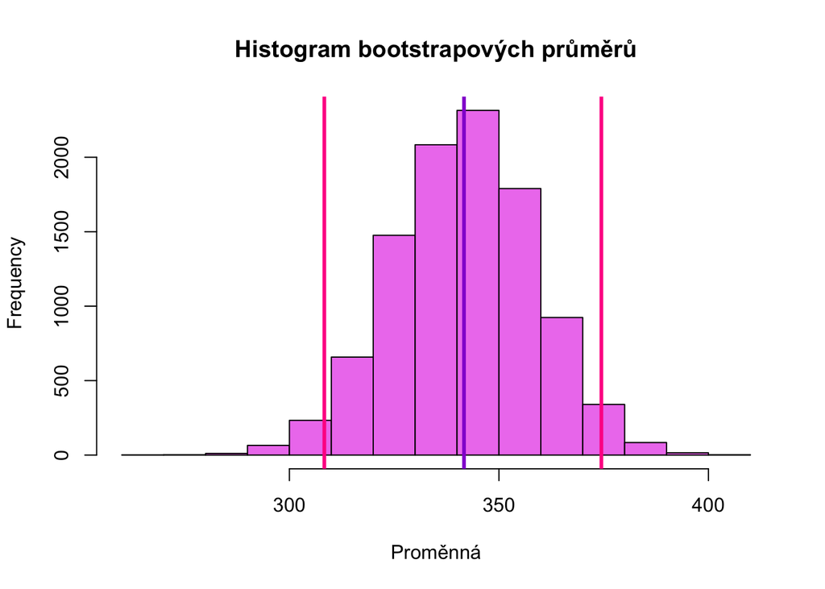

```r
promenna <- df$Size

boots <- list() # Prázdný seznam, do kterého se uloží bootstrapové výběry
B <- 10000 # Nastavení počtu bootstrapových výběrů
for(i in 1:B) boots[[i]] <- sample(promenna,replace=TRUE) # Náhodný výběr vzorku  z proměnné s opakováním
means <- unlist(lapply(boots,mean)) # Výpočet průměru z každého bootstrapového vzorku, transformace na čís. vektor

hist(means,col="violet",xlab="Proměnná",
     main="Histogram bootstrapových průměrů")

# Hodnota průměru původní proměnné
abline(v=mean(promenna),lwd=3,col="darkviolet")

# Bootstrapové intervaly spolehlivosti
abline(v=quantile(means,probs=c(0.025,0.975)),lwd=3,col="deeppink")
```

```r
# Výsledek bootstrapu
c(mean=mean(promenna),quantile(means,probs=c(0.025,0.975)))
```

```
    mean     2.5%    97.5%
341.6627 308.3355 374.4464
```

```r
# Funkce z DescTools
MeanCI(promenna,method="boot")
```

```
    mean   lwr.ci   upr.ci
341.6627 307.4940 375.2651
```

```r
BootCI(promenna,FUN = base::mean)
```

```
base::mean     lwr.ci     upr.ci
  341.6627   309.0973   375.1618
```

## Bodový a intervalový odhad rozdílu středních hodnot

- **bodový odhad**: konkrétní číslo, které udává rozdíl mezi průměry dvou populací nebo dvou různých vzorků
- **konfidenční interval**; rozsah, ve kterém se s určitou mírou jistoty nachází **rozdíl průměrů**

```r
MeanDiffCI(df$Size[df$CourseSuccess == 1],  # rozdělení podle kategorií ze sloupce CourseSuccess
           df$Size[df$CourseSuccess == 0],
           method="classic",                # Klasický přístup
           conf.level = 0.95,               # Hladina významnosti 95%
           sides="two.sided")               # oboustranný/jednostranný CI
```

```
  meandiff     lwr.ci     upr.ci
  79.19167 -319.58895  477.97229
```

### Dvouvýběrový t.test

```r
  t.test(df$Size ~ df$CourseSuccess)
```

```
    Welch Two Sample t-test

data:  df$Size by df$CourseSuccess
t = -0.80667, df = 2.1291, p-value = 0.5001
alternative hypothesis: true difference in means between group 0 and group 1 is not equal to 0
95 percent confidence interval:
 -477.9723  319.5890
sample estimates:
mean in group 0 mean in group 1
       265.3333        344.5250
```

# Bodové a intervalové odhady podílu a rozdílu podílů

```r
library(tidyverse)
library(DescTools)
load("/Users/majdikleckerova/Desktop/Math.RData")
df <- Math
```

## Bodový a intervalový odhad podílu

**Ruční výpočet**

```r
promenna <- df$Gender
p <- prop.table(table(promenna))[2]
n <- length(promenna)
alpha <- 0.05
q.n <- qnorm(1-alpha/2)

# dolní mez
p - q.n*sqrt(p*(1-p)/n)
```

```
        z
0.4596469
```

```r
# horní mez
p + q.n*sqrt(p*(1-p)/n)
```

```
        z
0.6728832
```

### Jednovzorkový test proporcí - prop.test()

```r
promenna <- df$Gender
zvolena_kategorie <- sum(promenna == "z")
celkovy_pocet <- length(promenna)

prop.test(x = zvolena_kategorie, n = celkovy_pocet, conf.level = 0.95, alternative = "two.sided")
```

```
    1-sample proportions test with continuity correction

data:  zvolena_kategorie out of celkovy_pocet, null probability 0.5
X-squared = 1.2048, df = 1, p-value = 0.2724
alternative hypothesis: true p is not equal to 0.5
95 percent confidence interval:
 0.4531473 0.6731966
sample estimates:
        p
0.5662651
```

**Funkce z DescTools()**

```r
promenna <- df$CourseSuccess

x_pocet <- sum(promenna == 1, na.rm = TRUE)
celkovy_pocet <- sum(!is.na(promenna))

BinomCI(x = x_pocet, n = celkovy_pocet, conf.level = 0.95, method = "wald") # method = "wilson"
```

```
           est    lwr.ci upr.ci
[1,] 0.9638554 0.9237007      1
```

**BinomCI()** předpokládá binární data.

```r
promenna <- df$Grade
kategorie <- table(promenna)
MultinomCI(kategorie, conf.level = 0.95, method = "wald")
```

```
          est    lwr.ci     upr.ci
A+ 0.02409639 0.0000000 0.05708685
A  0.34939759 0.2468261 0.45196912
A- 0.19277108 0.1079061 0.27763603
B+ 0.12048193 0.0504506 0.19051326
B  0.27710843 0.1808208 0.37339606
B- 0.03614458 0.0000000 0.07629930
```

**MultinomCI()**, pokud máme víc kategorií

```r
promenna <- df$Grade

kategorie <- table(promenna)
celkovy_pocet <- sum(kategorie)

x_zvolena_kategorie <- kategorie["B-"]
podil_zvolene_kategorie <- x_zvolena_kategorie / celkovy_pocet
podil_zvolene_kategorie
```

```
        B-
0.03614458
```

```r
BinomCI(x = x_zvolena_kategorie, n = celkovy_pocet, conf.level = 0.95, method = "wald")
```

```
            est lwr.ci    upr.ci
[1,] 0.03614458      0 0.0762993
```

Převod na **Binomické rozdělení** (zvolená kategorie, pro kterou počítáme podíl vs. podíl všech ostatních)

## Bodový a intervalový odhad rozdílu podílů

```r
promenna <- df$CourseSuccess
kategorie <- df$Gender

x1_pocet <- sum(promenna[kategorie == "m"] == 1, na.rm = TRUE)
x1_celkem <- sum(kategorie == "m", na.rm = TRUE)

x2_pocet <- sum(promenna[kategorie == "z"] == 1, na.rm = TRUE)
x2_celkem <- sum(kategorie == "z", na.rm = TRUE)

BinomCI(x = x1_pocet, n = x1_celkem, method = "wald")
```

```
           est    lwr.ci upr.ci
[1,] 0.9722222 0.9185403      1
```

```r
BinomCI(x = x2_pocet, n = x2_celkem, method = "wald")
```

```
           est    lwr.ci upr.ci
[1,] 0.9574468 0.8997406      1
```

```r
BinomDiffCI(x1 = x1_pocet, n1 = x1_celkem,
            x2 = x2_pocet, n2 = x2_celkem,
            conf.level = 0.95,
            method = "wald")
```

```
            est     lwr.ci     upr.ci
[1,] 0.01477541 -0.0640393 0.09359013
```

### Dvouvzorkový test proporcí

```r
prop.test(c(x1_pocet, x2_pocet), c(x1_celkem, x2_celkem), alternative = "two.sided")
```

```
    2-sample test for equality of proportions with continuity correction

data:  c(x1_pocet, x2_pocet) out of c(x1_celkem, x2_celkem)
X-squared = 2.7162e-30, df = 1, p-value = 1
alternative hypothesis: two.sided
95 percent confidence interval:
 -0.07881472  0.10836554
sample estimates:
   prop 1    prop 2
0.9722222 0.9574468
```

# Testování statistických hypotéz v základních kontextech

```r
library(tidyverse)
library(DescTools)
```

- viz. papíry **(7)**, dělat shapiro test(fisherův), jednovýběrový, korelace, jejich přdpoklady

Testy jsou buď **parametrické** (Předpokládají určité rozdělení dat - př. normální) nebo **neparametrické**.

Před testem musíme stanovit:

1. **Nulová hypotéza (H0)**
2. **Alternativní hypotéza (H1)**
3. **Hladina významnosti (alpha)** … nejčastěji 0.05

**Definice p-hodnoty**

*p‐hodnota je pravděpodobnost realizace dat (z náhodného výběru, experimentu), která ještě více odporují nulové hypotéze 𝐻0 než nyní napozorovaná realizace, počítaná za přijatých statistických předpokladů. P‐hodnota se odvozuje od zvoleného data generujícího procesu dat (statistického modelu); a je‐li špatně zvolen, je nesprávná (proto je třeba vždy kontrolovat splnění předpokladů). Jde tak o pravděpodobnost založenou na příslušném statistickém modelu, že data by mohla více „svědčit” proti nulové hypotéze 𝐻0, než jak byla v současnosti napozorován.a*

Hodnocení pomocí **p-value**:

1. **p-value** <= **alpha** … Zamítáme Nulovou hypotézu (H0), platí alternativní hypotéza (H1)
2. **p-value** > **alpha** … Ponecháváme Nulovou hypotézu (H0), platí.

## Testy souvislosti dvou a více proměnných

1. **Chí-kvadrát test**
- test nezávislosti dvou kategorických proměnných
- vstupem je buď **tabulka četností**, nebo přímo **dvojice** proměnných
- **předpoklad**: všechny očekávané četnosti jsou větší než **5**

**Test**:

- **H(0)** Proměnná 1 a Proměnná 2 spolu nesouvisí.
- **H(1)** Proměnná 1 a Proměnná 2 spolu souvisí.

```r
promenna_1 <- df$Gender
promenna_2 <- df$Grade

tabulka <- table(promenna_1, promenna_2)

# Výpočet očekávaných četností
test <- chisq.test(tabulka, simulate.p.value = FALSE)
ocekavane <- test$expected

print(ocekavane)
```

```
          promenna_2
promenna_1        A+        A       A-       B+         B       B-
         m 0.8674699 12.57831 6.939759 4.337349  9.975904 1.301205
         z 1.1325301 16.42169 9.060241 5.662651 13.024096 1.698795
```

```r
all(ocekavane > 5)
```

```
[1] FALSE
```

Vrátí **TRUE** nebo **FALSE** , ověření předpokladu.

```r
chisq.test(promenna_1, promenna_2)
```

```
    Pearson's Chi-squared test

data:  promenna_1 and promenna_2
X-squared = 8.2922, df = 5, p-value = 0.1408
```

2. **Fisherův exaktní test**
- používá se, není li splněn předpoklad **chí-kvadrát testu**

```r
fisher.test(promenna_1, promenna_2)
```

```
    Fisher's Exact Test for Count Data

data:  promenna_1 and promenna_2
p-value = 0.1258
alternative hypothesis: two.sided
```

3. **cor.test()**
- zjištění, zda existuje statisticky významná **souvislost** (korelace) mezi dvěma proměnnými.
- vrátí **korelační koeficient** a **p-hodnotu**, říkající, zda je tento vztah statisticky významný.
- **Předpoklad**: obě proměnné jsou **číselné**!

**Test:**

- **H(0)**: Korelace mezi těmito dvěma proměnnými neexistuje; je nulová.
- **H(1)**: Korelace mezi těmito dvěma proměnnými existuje; není nulová.

```r
promenna_1 <- df$Size
promenna_2 <- df$Rank

cor.test(promenna_1, promenna_2) # method = pearson, spearman , kellner
```

```
    Pearson's product-moment correlation

data:  promenna_1 and promenna_2
t = 4.3397, df = 81, p-value = 4.086e-05
alternative hypothesis: true correlation is not equal to 0
95 percent confidence interval:
 0.2412475 0.5943462
sample estimates:
      cor
0.4343363
```

## CI pro střední hodnotu

4. **Jednovýběrový t.test**
- Porovnává **průměr** jedné sady dat s nějakou **konkrétní hodnotou** (hypotetickým průměrem)
- **Předpoklad**: data jsou normálně rozdělena

**Test**:

- **H(0)**: Průměr proměnné se rovná … . (Nelze prokázat, že se průměr proměnné liší od …)
- **H(1)**: Průměr proměnné se liší od … .

```r
promenna <- df$Size
mean(promenna)
```

```
[1] 341.6627
```

```r
t.test(promenna, mu = 300)
```

```
    One Sample t-test

data:  promenna
t = 2.4612, df = 82, p-value = 0.01595
alternative hypothesis: true mean is not equal to 300
95 percent confidence interval:
 307.9879 375.3374
sample estimates:
mean of x
 341.6627
```

## CI pro podíl

5. **Jednovýběrový prop.test()**
- Pro **kategorickou** proměnnou; zjišťuje, zda je **podíl** nějaké kategorie stejný jako očekávaná hodnota ze vzorku.

**Test:**

- **H(0)**: Podíl v celé populaci je roven očekávané hodnotě … .
- **H(1)**: Podíl v celé populaci se liší od očekávané hodnoty … .

```r
promenna <- df$Grade
celkovy_pocet <- length(promenna)
zvolena_kategorie <- sum(promenna == "A")

zvolena_kategorie/celkovy_pocet
```

```
[1] 0.3493976
```

```r
prop.test(x = zvolena_kategorie, n = celkovy_pocet, conf.level = 0.95, alternative = "two.sided")
```

```
    1-sample proportions test with continuity correction

data:  zvolena_kategorie out of celkovy_pocet, null probability 0.5
X-squared = 6.9398, df = 1, p-value = 0.00843
alternative hypothesis: true p is not equal to 0.5
95 percent confidence interval:
 0.2501937 0.4626888
sample estimates:
        p
0.3493976
```

```r
# parametr alternative: zda je podíl/průměr odlišný v obou směrech - menší/větší
```

## Testy normality

6. **Shapiro-Wilkův test normality**
- Vhodný pro malé až střední vzorky, **W** … čím blíže k 1, tím blíže ke **Gaussovskému rozdělení**

**Test:**

- **H(0)**: Data mají normální rozdělení.
- **H(1)**: Data nemají normální rozdělení.

```r
promenna <- df$Size
shapiro.test(promenna)
```

```
    Shapiro-Wilk normality test

data:  promenna
W = 0.9502, p-value = 0.002845
```

**Alternativní testy tvaru rozdělení**

```r
library(nortest)
library(DescTools)
library(readxl)
df <- read_excel("/Users/majdikleckerova/Desktop/DataDetiMin.xlsx")
promenna <- df$VYSKA
# pro použití na malých vzorcích, kde neznáme mean a sd
lillie.test(promenna)
```

```
    Lilliefors (Kolmogorov-Smirnov) normality test

data:  promenna
D = 0.047385, p-value = 0.1528
```

```r
# založen na kumulativní distribuční funkci, citlivější na odchylky v ocasech
ad.test(promenna)
```

```
    Anderson-Darling normality test

data:  promenna
A = 0.64673, p-value = 0.09061
```

```r
AndersonDarlingTest(promenna, null = "pnorm", mean = mean(promenna), sd = sd(promenna))
```

```
    Anderson-Darling test of goodness-of-fit
    Null hypothesis: Normal distribution
    with parameters mean = 162.071, sd = 9.881

data:  promenna
An = 0.64673, p-value = 0.6048
```

# Hodnocení vzájemné souvislosti dvou číselných proměnných (tvar, směr, síla)

```r
library(tidyverse)
library(readxl)
library(GGally)
df <- read_excel("/Users/majdikleckerova/Desktop/DataDetiMin.xlsx")
```

## Tvar souvislosti

- popisuje, jaký je vzorec vztahu mezi dvěma proměnnými
1. **Lineární**: data se dají dobře přiblížit přímkou
2. **Nelineární**: souvislost má jiný než lineární tvar (kvadratický, exponenciální, logaritmický)
3. **Žádný jasný tvar**: když data neukazují žádný konkrétní vztah
- určujeme podle:
1. **scatter-plotu**: lze vidět, zda data tvoří přímku, křivku nebo nesouvislý vzor
2. **testováním hypotéz**
3. **modelováním**

### Rozptylový graf

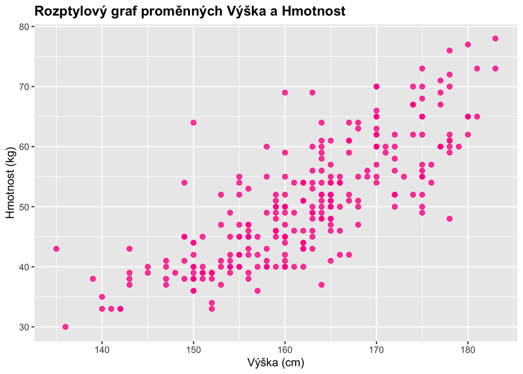

```r
df %>%
  ggplot(aes(x = VYSKA, y = HMOTN)) +
  geom_point(color = "deeppink", size = 2, alpha = 0.8) +
  labs(title = "Rozptylový graf proměnných Výška a Hmotnost",x = "Výška (cm)",y = "Hmotnost (kg)") +
  theme(plot.title = element_text(face = "bold"))
```

## Směr souvislosti

1. **přímý**: kladný vztah; pokud jedna proměnná roste, druhá roste také a naopak
2. **nepřímý**: záporný vztah; pokud jedna proměnná roste, druhá klesá
3. **žádný**: žádný systematický směr
- určujeme podle: **korelační koeficient**; **-** značí **nepřímý vztah**, **+** značí **přímý vztah**

### Kovariance

Statistická míra, která nám ukazuje, jak dvě náhodné proměnné **variují** společně.

- **Pozitivní** kovariance: vzájemný vztah je pozitivní (obě proměnné rostou, nebo klesají společně)
- **Negativní** kovariance: vzájemný vztah je negativní (jedna proměnná roste, zatímco druhá klesá)

```r
promenna_1 <- df$VYSKA
promenna_2 <- df$HMOTN
cov(promenna_1, promenna_2,use="complete.obs")
```

```
[1] 79.42201
```

## Síla souvislosti

- popisuje, jak těsně data sledují daný vztah:
- určujeme podle:

### Korelační koeficient

1. r = 0; **žádná**
2. r = 0.01 - 0.19; **velmi slabá**
3. r = 0.20 - 0.39; **slabá**
4. r = 0.40 - 0.59; **střední**
5. r = 0.60 - 0.79; **silná**
6. r = 0.80 - 1.00; **velmi silná**

```r
cor(df$VYSKA, df$HMOTN)
```

```
[1] 0.7956237
```

**Interpretace korelačního koeficientu**: **přímý** směr souvislosti (výška a váha rostou spolu), **silná** souvislost

- korelaci sinusoidy nezachytí, střídání kladných a záporných korelací
- nezachytává korelaci u hodně nelineárních vztahů - kvadratický tvar, kruhovitý tvar (nelineární regrese , Spearmanova korelace)

### Korelační tabulka

```r
# Rozdělení proměnné 1 do intervalů
promenna_1 <- df$VYSKA
promenna_2 <- df$HMOTN
promenna_1.c <- cut(promenna_1,
               breaks = c(0, 140, 150, 160, 170, 180, Inf),
               labels = c("<140","140-150", "150-160", "160-170", "170-180", ">180"))

# Rozdělení proměnné 2 do intervalů
promenna_2.c <- cut(promenna_2,
               breaks = c(0,40, 50, 60, 70, 80, Inf),
               labels = c("<40","40-50", "50-60", "60-70", "70-80", ">80"))

# Vytvoření korelační tabulky
table(promenna_1.c, promenna_2.c)
```

```
            promenna_2.c
promenna_1.c <40 40-50 50-60 60-70 70-80 >80
     <140      4     1     0     0     0   0
     140-150  22     8     1     1     0   0
     150-160  26    44    12     1     0   0
     160-170   3    31    42    18     0   0
     170-180   0     4    21    19     5   0
     >180      0     0     0     1     3   0
```

### Korelační matice

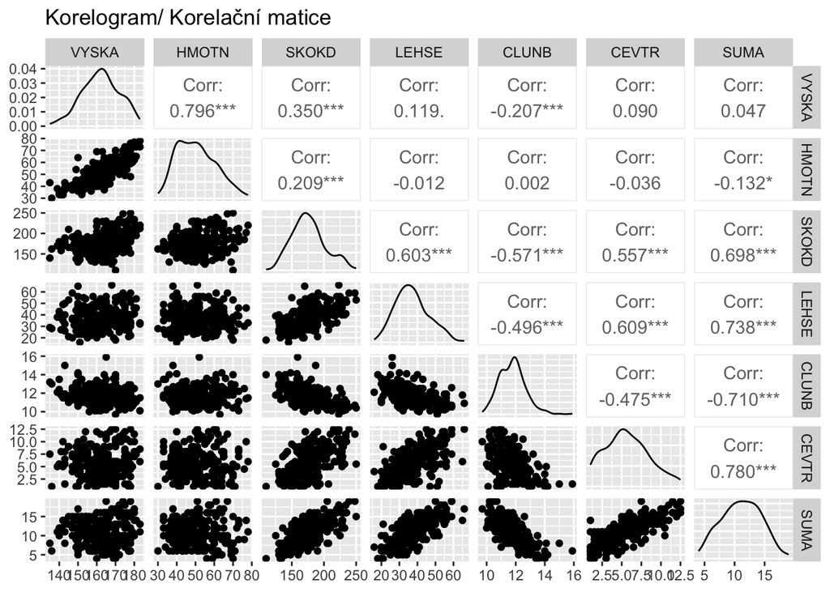

```r
zvolene_sloupce <- df[c("VYSKA", "HMOTN", "SKOKD", "LEHSE", "CLUNB", "CEVTR", "SUMA")]
ggpairs(zvolene_sloupce, title="Korelogram/ Korelační matice")
```

**koeficient determinace**

- R**2; míra vyjadřující, jak dobře lineární regresní model vysvětluje variabilitu závislé proměnné
- podíl vysvětlené variability oproti celkové variabilitě
- **R^2 = < 0 ; 1 >**; 0 … model nevysvětluje žádnou variabilitu; 1 … model vysvětluje veškerou variabilitu

## Test:

- **H(0)**: Korelace mezi těmito dvěma proměnnými neexistuje; je nulová.
- **H(1)**: Korelace mezi těmito dvěma proměnnými existuje; není nulová.

```r
promenna_1 <- df$VYSKA
promenna_2 <- df$HMOTN

cor.test(promenna_1, promenna_2) #method = spearman když vztah je monotónní není nutně lineární,
```

```
    Pearson's product-moment correlation

data:  promenna_1 and promenna_2
t = 21.38, df = 265, p-value < 2.2e-16
alternative hypothesis: true correlation is not equal to 0
95 percent confidence interval:
 0.7469170 0.8358376
sample estimates:
      cor
0.7956237
```

# Regresní přímka (rovnice regresní přímky)

```r
library(DescTools)
library(GGally)
library(tidyverse)
```

## Bodový graf (scatter plot) s odhadem regresní přímky

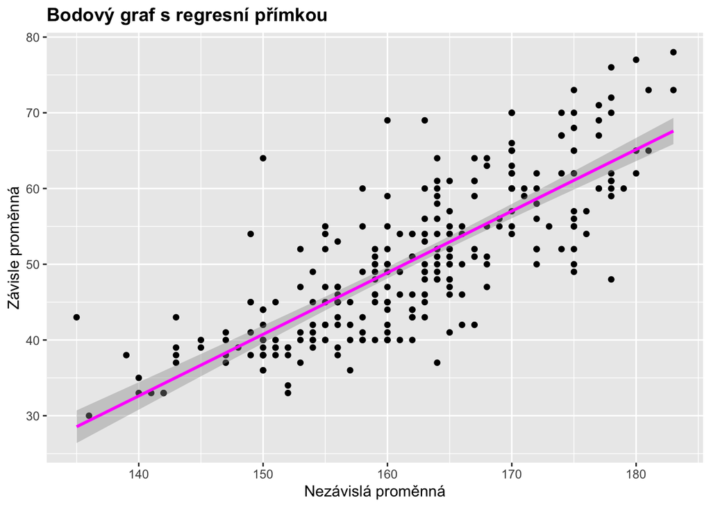

```r
nezavisla_promenna <- df$VYSKA
zavisla_promenna <- df$HMOTN

df %>%
  ggplot(aes(x = nezavisla_promenna, y = zavisla_promenna)) +
  geom_point() +
  labs(title = "Bodový graf s regresní přímkou", x = "Nezávislá proměnná", y = "Závisle proměnná") +
  theme(plot.title = element_text(face = "bold")) +
  geom_smooth(method = "lm", se = TRUE, color = "magenta")
```

```r
# Přidání regresní přímky (parametr lm značí lineární regresi, parametrem se=FALSE nezobrazíme intervaly spolehlivosti)
```

## Rovnice regresní přímky

- **Y = B0 + B1 * X + e**
- **Y** … závislá proměnná
- **X** … nezávislá proměnná
- **B0** … intercept (průsečík s osou y) = `mean(y) - b1 * mean(x)`
- **B1** … sklon regresní přímky, o kolik se změní y když posun x o jendu jednotku, záporný - klesá, kladný - roste = `(suma(xi - mean(x))*(yi - mean(y)))/suma[(xi-mean(x))**2]`
- **e** … náhodný termín, reziduální chyba (odchylka skutečných hodnot y od predikovaných) ; ei = |yi - výběrová(yi)|

```r
# parametry lm se zadávají v pořadí "závisle proměnná" (u nás na ose y)" ~ "nezávisle proměnná" (u nás na ose x)
regrese <- lm(zavisla_promenna ~ nezavisla_promenna , data = df)
regrese
```

```
Call:
lm(formula = zavisla_promenna ~ nezavisla_promenna, data = df)

Coefficients:
       (Intercept)  nezavisla_promenna
          -81.2790              0.8135
```

```r
intercept <- coef(regrese)[1]     # Průsečík s osou y
smernice <- coef(regrese)[2]      # Směrnice
cat("Rovnice regresní přímky: Y =", intercept, "+", smernice, "* X")
```

```
Rovnice regresní přímky: Y = -81.27901 + 0.8134979 * X
```

## Souhrn výstupu jednoduchého lineárního regresního modelu

```r
summary(regrese)
```

```
Call:
lm(formula = zavisla_promenna ~ nezavisla_promenna, data = df)

Residuals:
     Min       1Q   Median       3Q      Max
-15.5236  -3.9997  -0.6267   3.4923  23.2543

Coefficients:
                    Estimate Std. Error t value Pr(>|t|)
(Intercept)        -81.27901    6.17813  -13.16   <2e-16 ***
nezavisla_promenna   0.81350    0.03805   21.38   <2e-16 ***
---
Signif. codes:  0 '***' 0.001 '**' 0.01 '*' 0.05 '.' 0.1 ' ' 1

Residual standard error: 6.132 on 265 degrees of freedom
Multiple R-squared:  0.633, Adjusted R-squared:  0.6316
F-statistic: 457.1 on 1 and 265 DF,  p-value: < 2.2e-16
```

- Odhady regresních koeficientů (Estimate)
- Test o nulovosti koeficientů (Pr(>|t|) < 0.05, pak se koeficient vyznamne lisi od nuly)
- Multiple R-squared … procento variability zavisle promenne